# proposal

Team members: Carter Athens, Max Ruehle, Zihao Han

Project coordinator: Carter Athens

Link to the data source: https://www.kaggle.com/ramamet4/app-store-apple-data-set-10k-apps

```r
AppleStore <- read.csv(file="AppleStore.csv", header=TRUE, sep=",")
summary(AppleStore)
```

```
##        X               id
##  Min.   :    1   Min.   :2.817e+08
##  1st Qu.: 2090   1st Qu.:6.001e+08
##  Median : 4380   Median :9.781e+08
##  Mean   : 4759   Mean   :8.631e+08
##  3rd Qu.: 7223   3rd Qu.:1.082e+09
##  Max.   :11097   Max.   :1.188e+09
##
##                                                                                       track_name
##  Mannequin Challenge                                                                       :   2
##  VR Roller Coaster                                                                         :   2
##  -The ç©´é\200ã\2013D- å\220ã\201®è¨\230æ¶åxå\217\215å°ç¥çµãå\217ã\201! ï½Mr.CURVEã\201ãã\201®ææ\210¦ç¶ ï½:   1
##  ! OH Fantastic Free Kick + Kick Wall Challenge                                            :   1
##  "Burn your fat with me!!"                                                                 :   1
##  "HOOK"                                                                                    :   1
##  (Other)                                                                                   :7189
##    size_bytes        currency       price         rating_count_tot
##  Min.   :5.898e+05   USD:7197   Min.   :  0.000   Min.   :      0
##  1st Qu.:4.692e+07              1st Qu.:  0.000   1st Qu.:     28
##  Median :9.715e+07              Median :  0.000   Median :    300
##  Mean   :1.991e+08              Mean   :  1.726   Mean   :  12893
##  3rd Qu.:1.819e+08              3rd Qu.:  1.990   3rd Qu.:   2793
##  Max.   :4.026e+09              Max.   :299.990   Max.   :2974676
##
##  rating_count_ver    user_rating    user_rating_ver      ver
##  Min.   :     0.0   Min.   :0.000   Min.   :0.000   1.0    : 317
##  1st Qu.:     1.0   1st Qu.:3.500   1st Qu.:2.500   1.1    : 266
##  Median :    23.0   Median :4.000   Median :4.000   1.2    : 218
##  Mean   :   460.4   Mean   :3.527   Mean   :3.254   1.0.0  : 187
##  3rd Qu.:   140.0   3rd Qu.:4.500   3rd Qu.:4.500   1.0.1  : 180
##  Max.   :177050.0   Max.   :5.000   Max.   :5.000   1.3    : 136
##                                                     (Other):5893
##  cont_rating           prime_genre   sup_devices.num ipadSc_urls.num
##  12+:1155    Games           :3862   Min.   : 9.00   Min.   :0.000
##  17+: 622    Entertainment   : 535   1st Qu.:37.00   1st Qu.:3.000
##  4+ :4433    Education       : 453   Median :37.00   Median :5.000
##  9+ : 987    Photo & Video   : 349   Mean   :37.36   Mean   :3.707
##              Utilities       : 248   3rd Qu.:38.00   3rd Qu.:5.000
##              Health & Fitness: 180   Max.   :47.00   Max.   :5.000
##              (Other)         :1570
##     lang.num         vpp_lic
##  Min.   : 0.000   Min.   :0.0000
##  1st Qu.: 1.000   1st Qu.:1.0000
##  Median : 1.000   Median :1.0000
##  Mean   : 5.435   Mean   :0.9931
##  3rd Qu.: 8.000   3rd Qu.:1.0000
##  Max.   :75.000   Max.   :1.0000
##
```

```r
head(AppleStore)
```

```
##   X        id                                         track_name
## 1 1 281656475                                    PAC-MAN Premium
## 2 2 281796108                          Evernote - stay organized
## 3 3 281940292    WeatherBug - Local Weather, Radar, Maps, Alerts
## 4 4 282614216 eBay: Best App to Buy, Sell, Save! Online Shopping
## 5 5 282935706                                              Bible
## 6 6 283619399                                   Shanghai Mahjong
##   size_bytes currency price rating_count_tot rating_count_ver user_rating
## 1  100788224      USD  3.99            21292               26         4.0
## 2  158578688      USD  0.00           161065               26         4.0
## 3  100524032      USD  0.00           188583             2822         3.5
## 4  128512000      USD  0.00           262241              649         4.0
## 5   92774400      USD  0.00           985920             5320         4.5
## 6   10485713      USD  0.99             8253             5516         4.0
##   user_rating_ver    ver cont_rating  prime_genre sup_devices.num
## 1             4.5  6.3.5          4+        Games              38
## 2             3.5  8.2.2          4+ Productivity              37
## 3             4.5  5.0.0          4+      Weather              37
## 4             4.5 5.10.0         12+     Shopping              37
## 5             5.0  7.5.1          4+    Reference              37
## 6             4.0    1.8          4+        Games              47
##   ipadSc_urls.num lang.num vpp_lic
## 1               5       10       1
## 2               5       23       1
## 3               5        3       1
## 4               5        9       1
## 5               5       45       1
## 6               5        1       1
```

```r
# The currency column only contains the value "USD" so it was dropped. Also columns vpp_lic, ver, and id are unnecessary/ meaningless. Then we need to drop any rows that contain invalid info.

df = subset(AppleStore, select = -c(currency, vpp_lic, ver, id))
dfCleaned <- df[complete.cases(df), ]
```

Overview of the data set: This data set contains details from over 7,000 Apple iOS mobile apps. These details will help us understand what makes an app successful. The columns that we are interested in are listed below.

“track_name”: App Name

“size_bytes”: Size (in Bytes)

“price”: Price amount

“rating_count_tot”: User Rating counts (for all version)

“rating_count_ver”: User Rating counts (for current version)

“user_rating” : Average User Rating value (for all version)

“user_rating_ver”: Average User Rating value (for current version)

“cont_rating”: Content Rating

“prime_genre”: Primary Genre

“sup_devices.num”: Number of supporting devices

“ipadSc_urls.num”: Number of screenshots showed for display

“lang.num”: Number of supported languages

Some questions this data set can answer: Does the size of the app matter in comparison to its ratings? How does genre relate to the ratings of the app? Do games on average get higher ratings? Which genre has the lowest ratings? what does the app usually cost? Do certain genres of apps typically cost more than others?

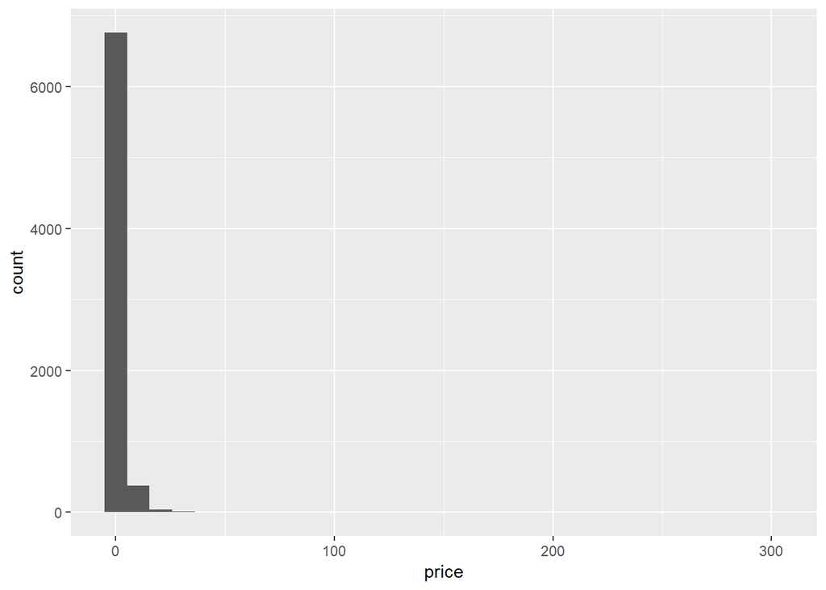

```r
library(ggplot2)
library(dplyr)
ggplot(dfCleaned,aes(x=price))+geom_histogram()
```

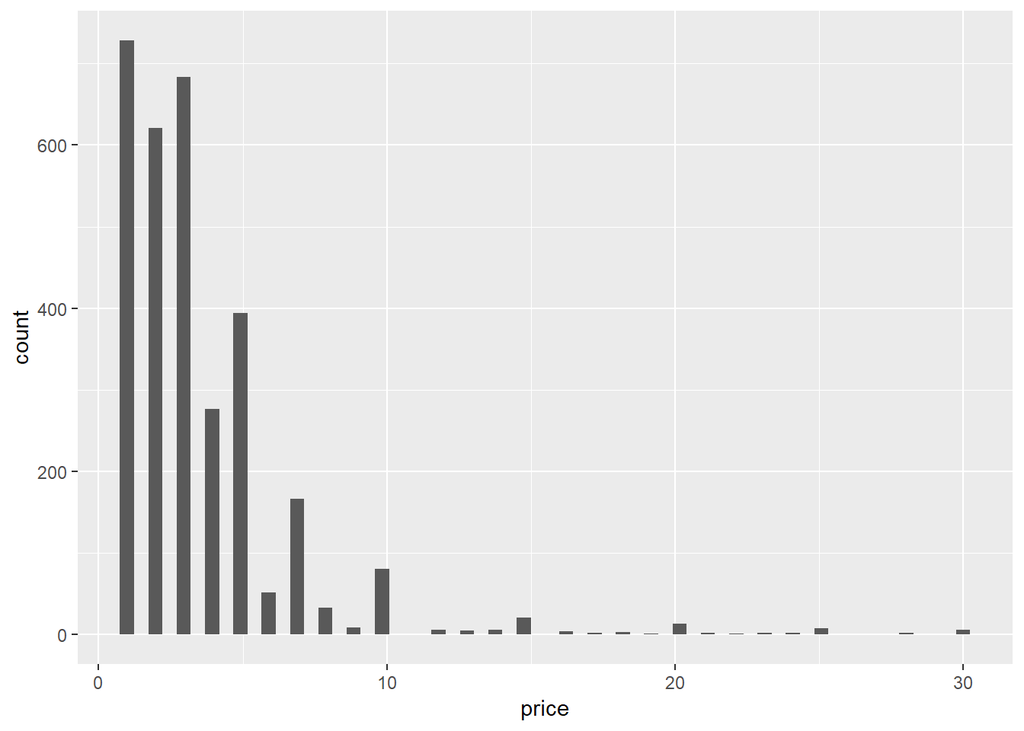

```r
a<-dfCleaned%>%filter(price<=30)%>%filter(price>0)
ggplot(a,aes(x=price))+geom_histogram(bins = 60)
```

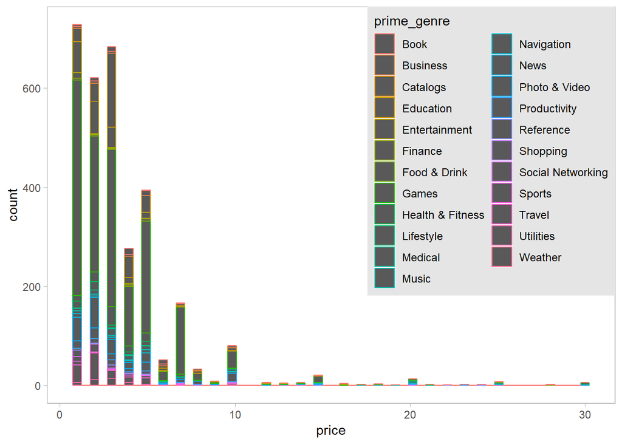

```r
ggplot(a,aes(x=price,colour=prime_genre))+geom_histogram(bins = 60)+theme_light()+theme(legend.background = element_rect(fill="gray90", size=.5, linetype="dotted"),legend.justification=c(1,1), legend.position=c(1,1),legend.text = element_text( size = 9),panel.grid =element_blank())
```

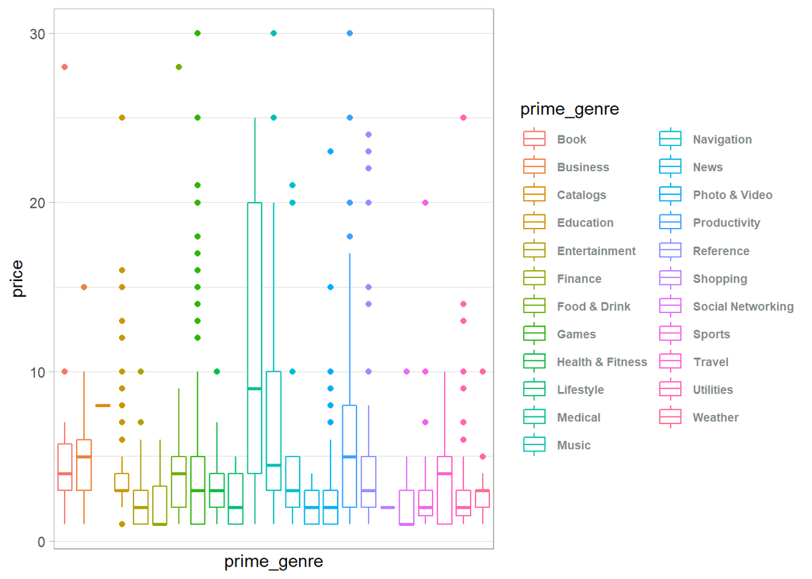

```r
ggplot(a,aes(x=prime_genre,y=price,colour=prime_genre))+geom_boxplot()+scale_x_discrete(breaks=NULL)+theme(legend.title = element_text(color="18", size=9, face="bold"))+theme_light()+theme(legend.text = element_text(color="azure4", size = 7, face = "bold"))
```

```r
summary(dfCleaned$price)
```

```
##    Min. 1st Qu.  Median    Mean 3rd Qu.    Max.
##   0.000   0.000   0.000   1.726   1.990 299.990
```

```r
summary(a$price)
```

```
##    Min. 1st Qu.  Median    Mean 3rd Qu.    Max.
##   0.990   1.990   2.990   3.598   4.990  29.990
```

Do games with more supported devices get higher ratings? More ratings? Does the number of supported languages matter to ratings? Do certain genres of apps have more supported languages?

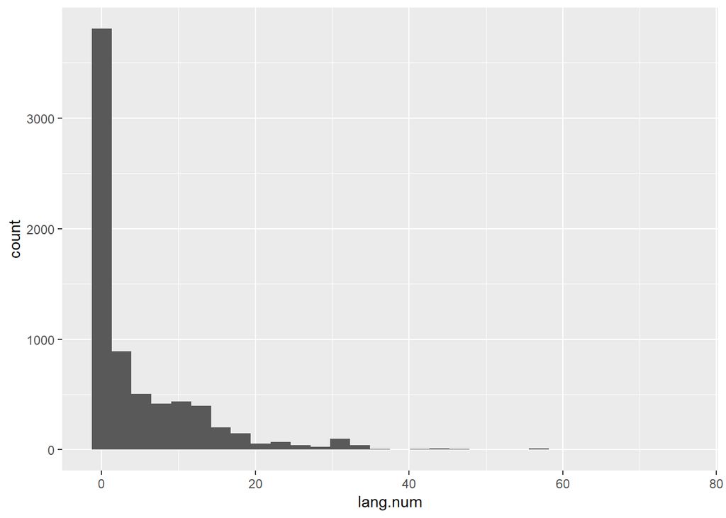

```r
ggplot(dfCleaned,aes(x=lang.num))+geom_histogram()
```

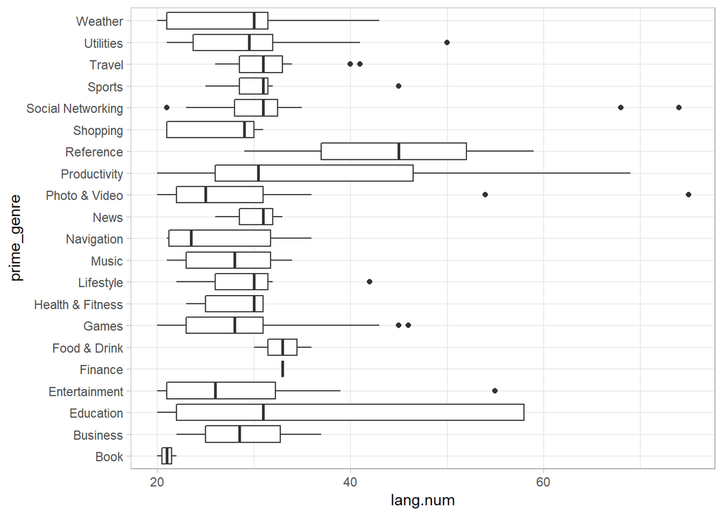

```r
b<-dfCleaned%>%filter(lang.num>=20)

ggplot(b,aes(y=lang.num,x= prime_genre))+geom_boxplot()+ coord_flip()+theme_light()
```

price comparation for each medical apps

```
## geom_path: Each group consists of only one observation. Do you need to
## adjust the group aesthetic?
```

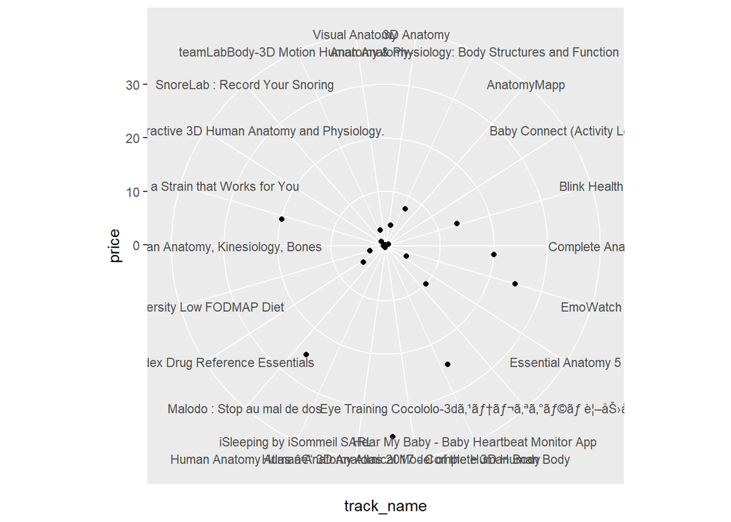

```r
#   Social Networking
c<-dfCleaned%>%filter(prime_genre=='Medical')%>%filter(X!=3633)
c$price<-sort(c$price)
ggplot(c,aes(x=track_name,y=price))+geom_path()+ geom_jitter()+coord_polar()
```